# Wellington Greenway: Crash Analysis

Corridor Study by Lakeview Urbanists

## Project Context

The Chicago Department of Transportation (CDOT) is proposing a **Neighborhood Greenway** on [Wellington Avenue](https://api.chicago.gov/filenet5/servlets/getDocumentContent?applicationId=CompleteStreets&documentId=%7BF0FB4197-0000-CD1D-9EA2-EC8C11B1EB46%7D), connecting the Leavitt Greenway to the Lakefront Trail. This proposed infrastructure is intended to be a family-friendly route, providing access to Hamlin Park, Alphonsus Academy, Wellington CTA station, and the lakefront.

**Key proposed features include:**

- **Advisory Bike Lanes** to encourage safer passing
- **Contraflow Lanes** to allow legal two-way cycling on one-way streets
- **Lowered Speed Limits** (20 mph) to improve safety for all road users

This analysis examines crash history specifically within the project boundaries: **Clybourn Avenue (West) to N Lake Shore Drive (East)**.

Data for this analysis is sourced from the [Traffic Crashes](https://data.cityofchicago.org/Transportation/Traffic-Crashes-Crashes/85ca-t3if/about_data) and [Traffic Crashes - People](https://data.cityofchicago.org/Transportation/Traffic-Crashes-People/u6pd-qa9d) datasets from the Chicago City Data Portal. This report was made by the [Lakeview Urbanists](https://lakeviewurbanists.com/). Signup for our newsletter to stay informed about advocacy opportunities for cycling infrastructure like this!

## Study Area Map

The map below highlights the specific corridor analyzed (purple line) and the 150ft buffer zone used to capture crashes impacting the street:

[interactive chart not shown]

## Demographics: Who is Involved?

Understanding the age of people involved in crashes helps assess the need for “family-friendly” infrastructure.

### Age Distribution of People Involved in Crashes

The chart below shows the age groups of all individuals involved in crashes on this corridor (drivers, passengers, cyclists, and pedestrians).

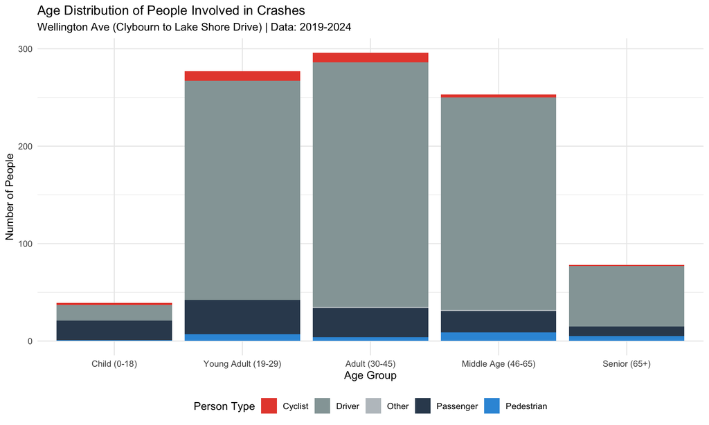

### Focus on Children (Ages 0-18)

```
## There have been **39 children** (under 18) involved in crashes on this corridor (2019-2024). Of those, **3 were walking or biking**.
```

## Temporal Analysis: When Do Crashes Happen?

Analyzing crash times helps us understand if students are at risk during school commute hours.

### All Crashes by Hour of Day

Crashes generally peak during the evening rush hour, but a consistent baseline exists throughout the day.

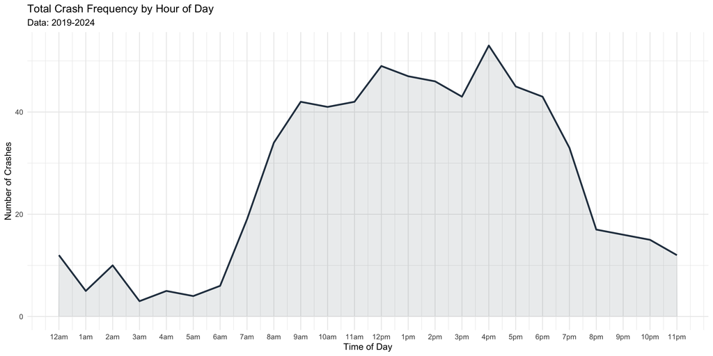

### Children Involved in Crashes by Hour

The chart below isolates crashes involving children (ages 0-18). Note the spikes that align with school commute times.

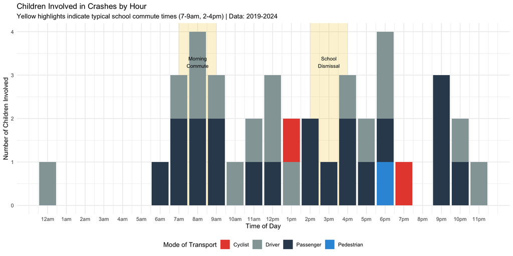

## Seasonal Analysis

Understanding how crashes vary by season helps identify whether weather conditions, seasonal travel patterns, or other factors influence road safety along the corridor.

### Total Crashes by Season

This chart shows the overall distribution of crashes across the four seasons (Data: 2019-2024).

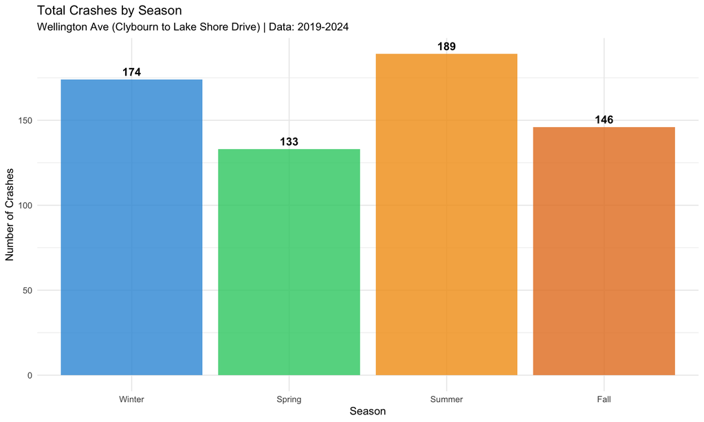

### Injuries by Season

This breakdown shows how injury severity varies across seasons.

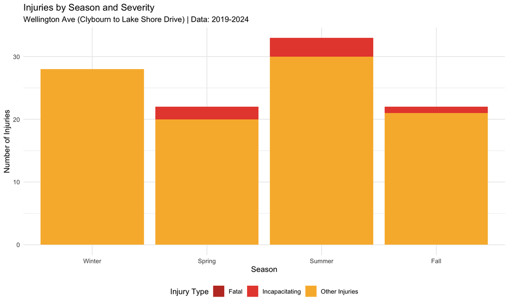

### Vulnerable Road Users by Season

Cyclist and pedestrian crashes show distinct seasonal patterns, often influenced by weather and travel mode choices.

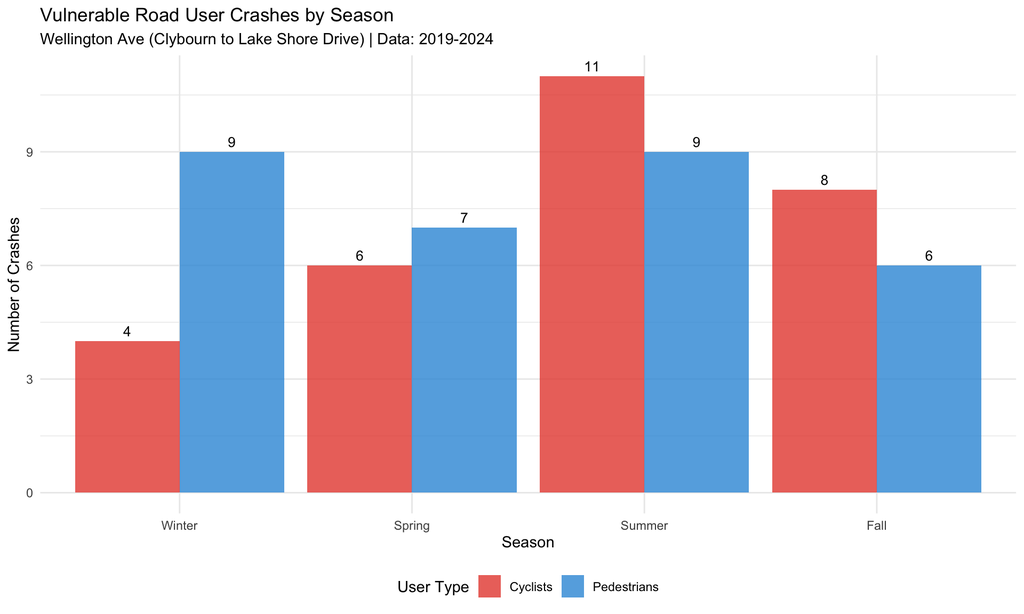

### Seasonal Summary Statistics

The table below provides a comprehensive overview of crashes, injuries, and vulnerable user involvement across all four seasons (Data: 2019-2024).

| Season | Total Crashes | Avg/Month | Total Injuries | Injury Rate | Cyclist Crashes | Pedestrian Crashes |
| --- | --- | --- | --- | --- | --- | --- |
| Winter | 174 | 58.0 | 28 | 16.1% | 4 | 9 |
| Spring | 133 | 44.3 | 22 | 16.5% | 6 | 7 |
| Summer | 189 | 63.0 | 33 | 17.5% | 11 | 9 |
| Fall | 146 | 48.7 | 22 | 15.1% | 8 | 6 |

## General Safety Summary

In the corridor from Clybourn to Lake Shore Drive (2019-2024):

- **642 Total reported crashes**
- **105 Total injuries reported**
- **29 crashes involved a cyclist**
- **31 crashes involved a pedestrian**

## Detailed Crash Statistics

The following tables provide a comprehensive breakdown of crash severity, vulnerable road users, and impacts on children in the corridor.

### Overall Crash Summary

This table summarizes the total impact of crashes along the Wellington Avenue corridor (Data: 2019-2024).

| Metric | Count |
| --- | --- |
| Total Crashes | 642 |
| Total Injuries (All Severities) | 105 |
| Incapacitating Injuries | 6 |
| Fatal Injuries | 0 |
| Hit-and-Run Crashes | 153 |
| Dooring Incidents | 5 |

### Vulnerable Road Users

Cyclists and pedestrians are particularly at risk in traffic crashes. This table shows the involvement and injury rates for these vulnerable road users (Data: 2019-2024).

| Metric | Count |
| --- | --- |
| Crashes Involving Cyclists | 29 |
| Cyclists Involved (People) | 29 |
| Cyclists Injured | 19 |
| Crashes Involving Pedestrians | 31 |
| Pedestrians Involved (People) | 31 |
| Pedestrians Injured | 26 |

### Children in Crashes

Given the proposed Neighborhood Greenway’s focus on “family-friendly” infrastructure, understanding how children are affected by crashes is critical (Data: 2019-2024).

| Metric | Value |
| --- | --- |
| Crashes Involving Children (0-18) | 33 |
| Children Involved in Crashes | 39 |
| Children Injured | 4 |
| % of All People in Crashes Who Are Children | 3% |

### High Injury Locations

This map shows where injuries (of any type) are most concentrated along the Wellington Avenue corridor (Data: 2019-2024).

[interactive chart not shown]

## Cyclist Crash Locations

This map shows all crashes involving cyclists along the Wellington Avenue corridor (Data: 2019-2024).

[interactive chart not shown]

## Pedestrian Crash Locations

This map shows all crashes involving pedestrians along the Wellington Avenue corridor (Data: 2019-2024).

[interactive chart not shown]

## Crash Clusters

This heat map visualization shows where crashes are concentrated along the Wellington Avenue corridor (Data: 2019-2024).

[interactive chart not shown]